# Inflation Dynamics Time Series Project

Author

Peyton Ramsey

# Introduction

The Vector Error Correction Model (VECM) is a multivariate time series method that extends the Vector Autoregression (VAR) framework to handle cointegrated I(1) series. While VAR models differences of non-stationary series and discards long-run information, VECM explicitly incorporates the long-run equilibrium relationships among variables through an error correction term (ECT). When series are cointegrated, the ECT measures how far the system has deviated from its long-run path and drives gradual mean reversion back toward equilibrium. This makes VECM well-suited for macroeconomic applications where variables share a common stochastic trend.

Our research question is: **How do demand, supply, and labor market shocks dynamically affect U.S. inflation over time?**

VECM is the appropriate model for this dataset for two reasons. First, Augmented Dickey-Fuller (ADF) tests confirm that all four series are integrated of order one, I(1), meaning they are non-stationary in levels but stationary after first differencing. Second, the Johansen test identifies three cointegrating relationships among the variables, meaning the series share long-run equilibrium paths and a VAR on first differences alone would discard meaningful information. Together, these findings satisfy the two necessary conditions for VECM estimation.

# Method

## Vector Error Correction Model

The VECM for a $p$-variable system with $k-1$ lags of differences is written as:

$$\Delta Y_t = \alpha \beta' Y_{t-1} + \sum_{i=1}^{k-1} \Gamma_i \Delta Y_{t-i} + \varepsilon_t$$

where:

- $Y_t$ is a $p \times 1$ vector of I(1) variables at time $t$
- $\Delta Y_t = Y_t - Y_{t-1}$ is the vector of first differences
- $\beta$ is the $p \times r$ matrix of cointegrating vectors, the long-run equilibrium relationships. While $\beta' Y_{t-1}$ are the error correction terms (ECTs)
- $\alpha$ is the $p \times r$ matrix of loading (adjustment) coefficients, how quickly each variable corrects back toward equilibrium after a deviation
- $\Gamma_i$ are $p \times p$ matrices of short-run dynamic coefficients, capturing transitory effects of lagged changes
- $\varepsilon_t$ is a $p \times 1$ vector of white noise errors
- $r$ is the cointegrating rank, determined by the Johansen trace test

The cointegrating rank $r$ is tested using the Johansen trace statistic. The null hypothesis for each rank $r_0$ is that there are at most $r_0$ cointegrating relationships. Starting from $r_0 = 0$ and increasing, we reject until the test statistic falls below the critical value. The first $r_0$ we fail to reject is our rank estimate.

## Toy Example

To illustrate the mechanics of VECM, we simulate two cointegrated I(1) series with a known long-run relationship ($y = x + \text{noise}$) and estimate the model.

```r
library(dplyr)
library(lubridate)
library(vars)
library(tseries)
library(ggplot2)
library(tidyr)
library(urca)
```

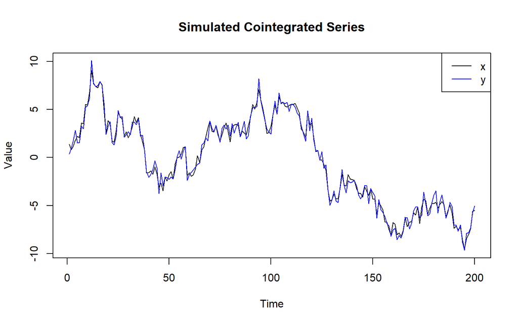

```r
set.seed(42)
n <- 200

# simulate two cointegrated i(1) series, x is a random walk, y tracks x with noise
x <- cumsum(rnorm(n, sd = 1))
y <- x + rnorm(n, sd = 0.5)

toy_df <- data.frame(x = x, y = y)

# plot series
matplot(toy_df, type = "l", lty = 1, col = c("black", "blue"),
        main = "Simulated Cointegrated Series", ylab = "Value", xlab = "Time")
legend("topright", legend = c("x", "y"), col = c("black", "blue"), lty = 1)
```

```r
# johansen trace test on toy data, expect r = 1
toy_jo <- ca.jo(toy_df, type = "trace", ecdet = "const", K = 2)
summary(toy_jo)
```

```
######################
# Johansen-Procedure #
######################

Test type: trace statistic , without linear trend and constant in cointegration

Eigenvalues (lambda):
[1]  4.158322e-01  9.347123e-03 -5.551115e-17

Values of teststatistic and critical values of test:

           test 10pct  5pct  1pct
r <= 1 |   1.86  7.52  9.24 12.97
r = 0  | 108.30 17.85 19.96 24.60

Eigenvectors, normalised to first column:
(These are the cointegration relations)

                 x.l2       y.l2   constant
x.l2      1.000000000  1.0000000  1.0000000
y.l2     -1.005710795 -0.2034168 -0.4038563
constant  0.005494881  1.5817165 -7.0195149

Weights W:
(This is the loading matrix)

         x.l2        y.l2      constant
x.d 0.3504638 -0.02406950  9.691924e-18
y.d 1.5333088 -0.02152063 -6.889195e-17
```

```r
# estimate vecm with r = 1 cointegrating relationship
toy_vecm <- cajorls(toy_jo, r = 1)
summary(toy_vecm$rlm)
```

```
Response x.d :

Call:
lm(formula = x.d ~ ect1 + x.dl1 + y.dl1 - 1, data = data.mat)

Residuals:
     Min       1Q   Median       3Q      Max
-2.97405 -0.64904 -0.03028  0.60562  2.55568

Coefficients:
      Estimate Std. Error t value Pr(>|t|)
ect1    0.3505     0.2128   1.647   0.1012
x.dl1   0.3638     0.1579   2.303   0.0223 *
y.dl1  -0.3768     0.1467  -2.568   0.0110 *
---
Signif. codes:  0 '***' 0.001 '**' 0.01 '*' 0.05 '.' 0.1 ' ' 1

Residual standard error: 0.9628 on 195 degrees of freedom
Multiple R-squared:  0.03322,   Adjusted R-squared:  0.01834
F-statistic: 2.233 on 3 and 195 DF,  p-value: 0.08564


Response y.d :

Call:
lm(formula = y.d ~ ect1 + x.dl1 + y.dl1 - 1, data = data.mat)

Residuals:
    Min      1Q  Median      3Q     Max
-3.5361 -0.6555 -0.0869  0.6799  3.0557

Coefficients:
      Estimate Std. Error t value Pr(>|t|)
ect1    1.5333     0.2290   6.696 2.23e-10 ***
x.dl1   1.4428     0.1700   8.489 5.22e-15 ***
y.dl1  -1.4255     0.1579  -9.029  < 2e-16 ***
---
Signif. codes:  0 '***' 0.001 '**' 0.01 '*' 0.05 '.' 0.1 ' ' 1

Residual standard error: 1.036 on 195 degrees of freedom
Multiple R-squared:  0.2975,    Adjusted R-squared:  0.2867
F-statistic: 27.52 on 3 and 195 DF,  p-value: 6.91e-15
```

# Application

## Data prep

```r
df <- read.csv("C:/Users/ramse/msba-courses/ds 809/project/PROJECT DATA.csv")

# Check column names + first rows
names(df)
```

```
[1] "observation_date" "CPIAUCSL"         "INDPRO"           "RSXFS"
[5] "UNRATE"
```

```r
head(df, 3)
```

```
  observation_date CPIAUCSL  INDPRO RSXFS UNRATE
1       1980-01-01     78.0 52.0679    NA    6.3
2       1980-02-01     79.0 52.0820    NA    6.3
3       1980-03-01     80.1 51.8700    NA    6.3
```

```r
str(df)
```

```
'data.frame':   642 obs. of  5 variables:
 $ observation_date: chr  "1980-01-01" "1980-02-01" "1980-03-01" "1980-04-01" ...
 $ CPIAUCSL        : num  78 79 80.1 80.9 81.7 82.5 82.6 83.2 83.9 84.7 ...
 $ INDPRO          : num  52.1 52.1 51.9 50.8 49.6 ...
 $ RSXFS           : int  NA NA NA NA NA NA NA NA NA NA ...
 $ UNRATE          : num  6.3 6.3 6.3 6.9 7.5 7.6 7.8 7.7 7.5 7.5 ...
```

```r
nrow(df)
```

```
[1] 642
```

```r
# mutate observation_date column to proper date format
df <- df %>%
    mutate(observation_date = ymd(observation_date)) %>%
    rename(Date = observation_date, # rename to date
           cpi = CPIAUCSL,
           ind_pro = INDPRO,
           retail_sales = RSXFS,
           unemp_rate = UNRATE) %>%
    drop_na()
str(df) # checking that date conversion worked
```

```
'data.frame':   407 obs. of  5 variables:
 $ Date        : Date, format: "1992-01-01" "1992-02-01" ...
 $ cpi         : num  138 139 139 139 140 ...
 $ ind_pro     : num  61.5 61.9 62.4 62.9 63.1 ...
 $ retail_sales: int  142419 142584 142120 143659 144239 145273 146743 146070 147932 149346 ...
 $ unemp_rate  : num  7.3 7.4 7.4 7.4 7.6 7.8 7.7 7.6 7.6 7.3 ...
```

## EDA

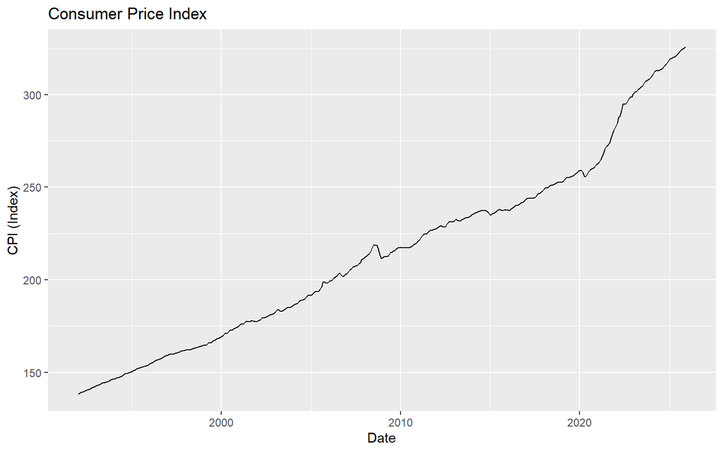

```r
# simple plots to observe any stationarity
ggplot(df, aes(x = Date, y = cpi)) +
  geom_line() +
  labs(title = "Consumer Price Index", x = "Date", y = "CPI (Index)")
```

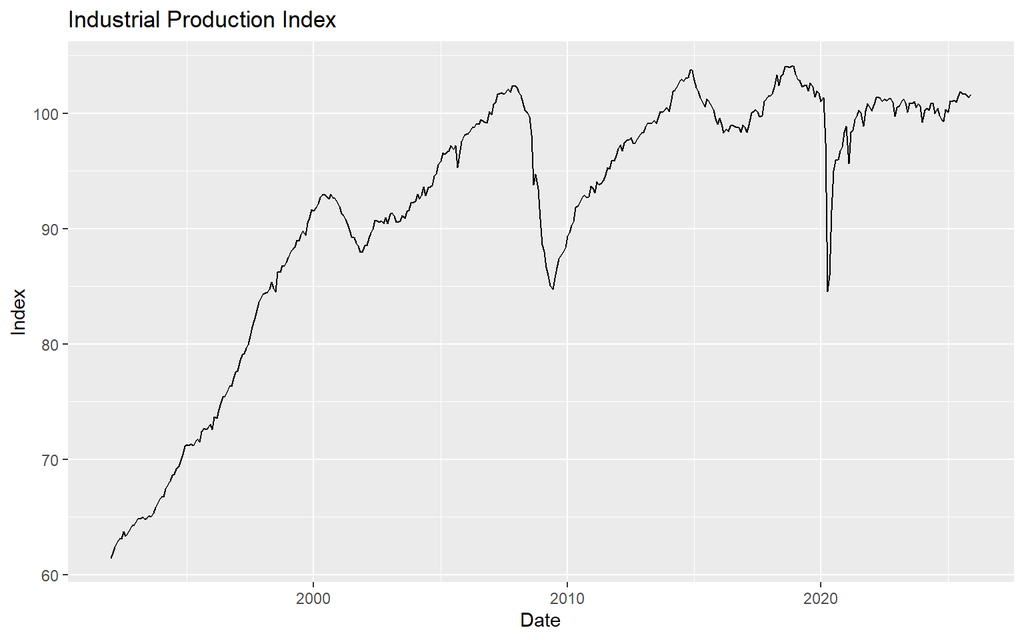

```r
ggplot(df, aes(x = Date, y = ind_pro)) +
  geom_line() +
  labs(title = "Industrial Production Index", x = "Date", y = "Index")
```

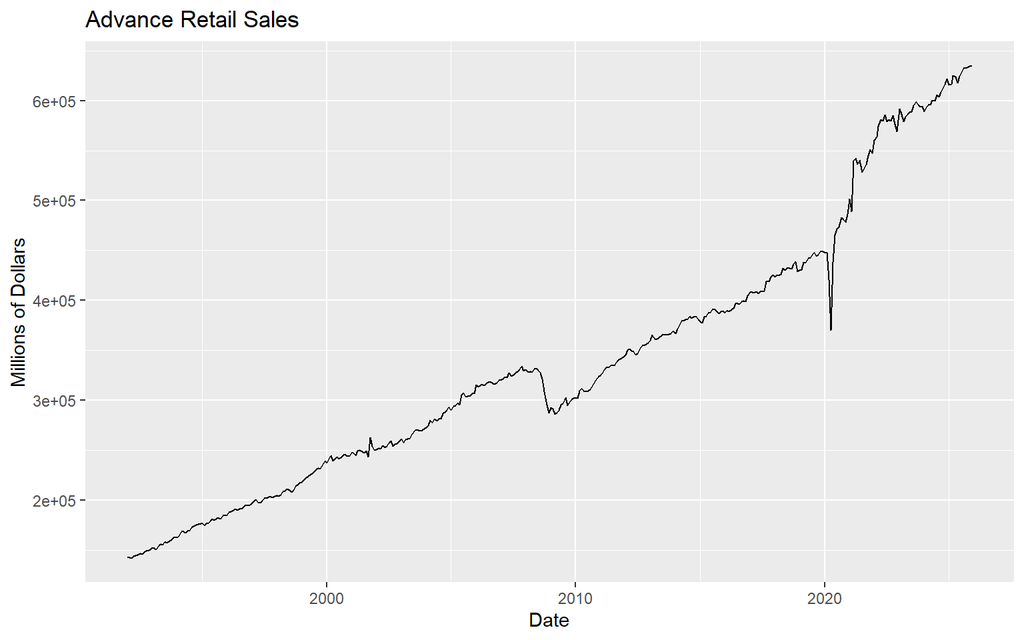

```r
ggplot(df, aes(x = Date, y = retail_sales)) +
  geom_line() +
  labs(title = "Advance Retail Sales", x = "Date", y = "Millions of Dollars")
```

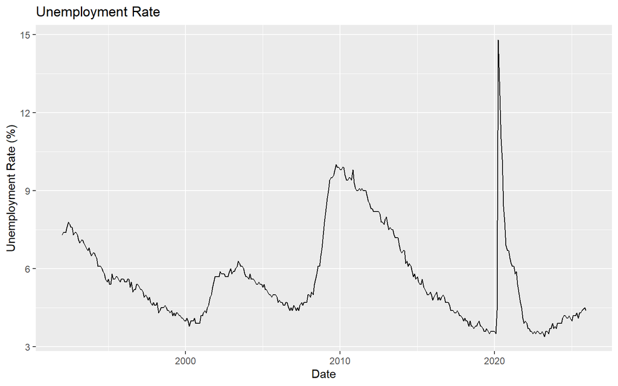

```r
ggplot(df, aes(x = Date, y = unemp_rate)) +
  geom_line() +
  labs(title = "Unemployment Rate", x = "Date", y = "Unemployment Rate (%)")
```

**Interpretation:** These plots are showing early signs of non-stationarity due to variance in mean and linearity in each plot.

## ADF Testing

Testing for stationarity in our plots, will help us determine which model is best to use (VAR or VECM). If it’s stationary, it’d be best to use VAR, otherwise if there is non-stationarity we will use run a Johansen test, if r = 0, there’s no cointegration and we can use VAR, if r >= 1, there is cointegration and we will use VECM.

```r
set.seed(123)

# selecting only columns to test excluding date (that's why there is a -1)
ts_df <- df[, -1]

# apply adf.test() function, 2 is saying to apply function to all columns
adf_results <- apply(ts_df, 2, adf.test)

# to view results, create a loop to view each p-value for each column
for (i in names(adf_results)) {
    cat("Results for", i, ":\n")
    print(adf_results[[i]]$p.value)
    cat("\n")
}
```

```
Results for cpi :
[1] 0.99

Results for ind_pro :
[1] 0.3626613

Results for retail_sales :
[1] 0.9854773

Results for unemp_rate :
[1] 0.3481156
```

**Interpretation:** All of the p-values have a value greater than 0.05, as a result, we fail to reject the null hypothesis. All four of the series are non-stationary in levels.

```r
# differencing the series, then re-running adf.test()
set.seed(123)
ts_df_diff <- df[, -1]

adf_test_diff <- function(x) {
  differenced_x <- diff(x, differences = 1)
  test_result <- adf.test(differenced_x, alternative = "stationary")
  return(test_result$p.value)
}

adf_results_diff <- apply(ts_df_diff, 2, adf_test_diff)

for (i in names(adf_results_diff)) {
    cat("Results for", i, ":\n")
    print(adf_results_diff[[i]])
    cat("\n")
}
```

```
Results for cpi :
[1] 0.01

Results for ind_pro :
[1] 0.01

Results for retail_sales :
[1] 0.01

Results for unemp_rate :
[1] 0.01
```

**Interpretation:** After one difference, all four of the p-values are < 0.05, this proves that they are I(1) or stationary after one difference. Next, we will perform a Johansen test.

## Johansen Test

```r
# finding BIC-selected lag from VARselect to set K in ca.jo()
lag_sel <- VARselect(df[, -1], lag.max = 8, type = "const")
lag_sel$selection  # look at SC(n), that's the BIC value
```

```
AIC(n)  HQ(n)  SC(n) FPE(n)
     7      3      2      7
```

```r
k_bic <- as.integer(lag_sel$selection["SC(n)"])
cat("BIC-selected lag order (SC/BIC):", k_bic, "\n")
```

```
BIC-selected lag order (SC/BIC): 2
```

```r
johansen_test <- ca.jo(ts_df, type = "trace", ecdet = "const", K = k_bic)
summary(johansen_test)
```

```
######################
# Johansen-Procedure #
######################

Test type: trace statistic , without linear trend and constant in cointegration

Eigenvalues (lambda):
[1] 2.043167e-01 6.741970e-02 4.373013e-02 1.720408e-02 9.400229e-17

Values of teststatistic and critical values of test:

           test 10pct  5pct  1pct
r <= 3 |   7.03  7.52  9.24 12.97
r <= 2 |  25.14 17.85 19.96 24.60
r <= 1 |  53.41 32.00 34.91 41.07
r = 0  | 145.97 49.65 53.12 60.16

Eigenvectors, normalised to first column:
(These are the cointegration relations)

                       cpi.l2    ind_pro.l2 retail_sales.l2 unemp_rate.l2
cpi.l2           1.000000e+00  1.000000e+00    1.0000000000  1.000000e+00
ind_pro.l2      -3.861803e-02  1.479700e-01   -0.7635146555 -9.972767e-02
retail_sales.l2 -4.128765e-04 -3.662607e-04   -0.0003857438 -3.425541e-04
unemp_rate.l2   -2.548636e+00 -7.506359e+00   -4.2916012768  6.947221e-01
constant        -6.738482e+01 -6.102513e+01   14.7846207816 -9.195585e+01
                     constant
cpi.l2           1.000000e+00
ind_pro.l2      -5.502274e+00
retail_sales.l2  9.528737e-05
unemp_rate.l2   -6.293957e+00
constant         2.846036e+02

Weights W:
(This is the loading matrix)

                      cpi.l2    ind_pro.l2 retail_sales.l2 unemp_rate.l2
cpi.d          -2.881671e-02 -9.906885e-04   -6.618812e-04  -0.001514045
ind_pro.d       5.862527e-04 -1.985706e-02   -8.501729e-04  -0.003274860
retail_sales.d -1.239254e+02 -9.960555e+01   -3.281351e+01  42.875449365
unemp_rate.d   -2.411769e-04  7.700718e-03    8.152472e-03   0.002120385
                    constant
cpi.d          -6.591971e-17
ind_pro.d       8.036810e-17
retail_sales.d -1.582541e-13
unemp_rate.d   -5.255047e-17
```

**Interpretation:** Reading the trace test, starting from the bottom at r = 0, then going upwards to r <= 3, we strongly reject the null hypothesis for r = 0 because 145.97 > 60.16. We again strongly reject the null hypothesis for r <= 1 because 53.41 > 41.07. We reject at all significance levels for r <= 2 because 25.14 exceeds the 10%, 5%, and 1% critical values (17.85, 19.96, and 24.60 respectively), though only marginally at 1%. For r <= 3, we fail to reject because 7.03 is smaller than all critical values (7.52, 9.24, and 12.97 for 10%, 5%, and 1% respectively). This is saying, there are 3 cointegrating relationships, confirming the assumption to use VECM based on the non-stationary findings above.

## Estimate VECM

```r
vecm_res <- cajorls(johansen_test, r = 3)
summary(vecm_res$rlm) # call summary on $rlm component directly bc summary() doesn't have a method for cajorls objects
```

```
Response cpi.d :

Call:
lm(formula = cpi.d ~ ect1 + ect2 + ect3 + cpi.dl1 + ind_pro.dl1 +
    retail_sales.dl1 + unemp_rate.dl1 - 1, data = data.mat)

Residuals:
     Min       1Q   Median       3Q      Max
-2.96932 -0.23078  0.01121  0.24301  1.97200

Coefficients:
                   Estimate Std. Error t value Pr(>|t|)
ect1             -3.047e-02  4.502e-03  -6.768 4.69e-11 ***
ect2              1.472e-03  2.027e-03   0.726    0.468
ect3              1.252e-05  1.769e-06   7.076 6.73e-12 ***
cpi.dl1           3.171e-01  4.895e-02   6.479 2.73e-10 ***
ind_pro.dl1      -4.452e-02  4.226e-02  -1.053    0.293
retail_sales.dl1  2.176e-05  4.965e-06   4.383 1.50e-05 ***
unemp_rate.dl1    1.075e-01  6.959e-02   1.544    0.123
---
Signif. codes:  0 '***' 0.001 '**' 0.01 '*' 0.05 '.' 0.1 ' ' 1

Residual standard error: 0.5114 on 398 degrees of freedom
Multiple R-squared:  0.5874,    Adjusted R-squared:  0.5802
F-statistic: 80.96 on 7 and 398 DF,  p-value: < 2.2e-16


Response ind_pro.d :

Call:
lm(formula = ind_pro.d ~ ect1 + ect2 + ect3 + cpi.dl1 + ind_pro.dl1 +
    retail_sales.dl1 + unemp_rate.dl1 - 1, data = data.mat)

Residuals:
     Min       1Q   Median       3Q      Max
-10.9776  -0.3176   0.0231   0.3339   3.2268

Coefficients:
                   Estimate Std. Error t value Pr(>|t|)
ect1             -2.012e-02  7.751e-03  -2.596  0.00978 **
```

[output cut: 51 more lines]

```
Coefficients:
                   Estimate Std. Error t value Pr(>|t|)
ect1              1.561e-02  4.554e-03   3.429 0.000670 ***
ect2             -5.076e-03  2.050e-03  -2.475 0.013724 *
ect3             -5.866e-06  1.789e-06  -3.279 0.001134 **
cpi.dl1          -2.049e-02  4.951e-02  -0.414 0.679249
ind_pro.dl1      -1.593e-01  4.275e-02  -3.727 0.000221 ***
retail_sales.dl1 -2.664e-05  5.022e-06  -5.305 1.87e-07 ***
unemp_rate.dl1   -4.076e-01  7.039e-02  -5.792 1.42e-08 ***
---
Signif. codes:  0 '***' 0.001 '**' 0.01 '*' 0.05 '.' 0.1 ' ' 1

Residual standard error: 0.5172 on 398 degrees of freedom
Multiple R-squared:  0.1865,    Adjusted R-squared:  0.1722
F-statistic: 13.04 on 7 and 398 DF,  p-value: 3.906e-15
```

**Interpretation:** Focusing on the cpi.d equation, an R-squared of 0.587 explains ~58% of month-to-month CPI changes. The ect1 of -0.03*** is the key error correction result, when CPI is above its long-run equilibrium, it corrects downward at ~3% per month. A cpi.dl1 of 0.317*** confirms strong inflation momentum, past CPI predicts future CPI. For the shock variables, the demand shock (retail_sales.dl1 = 2.18e-05***) is highly significant in the short run, confirming that demand-pull pressure from consumer spending drives near-term inflation. The supply shock (ind_pro.dl1) is insignificant in the CPI equation, suggesting industrial production does not directly transmit to inflation in the short run. The labor market shock (unemp_rate.dl1) is insignificant in the CPI equation but significant in the ind_pro.d and unemp_rate.d equations, indicating that labor market shocks primarily spread through production and employment channels rather than directly into prices in the short run.

## Cointegrating Vectors

```r
# cointegrating vectors (beta matrix) normalized to identity in first r rows
# rows: cpi, ind_pro, retail_sales, unemp_rate, constant; columns: ect1, ect2, ect3
round(johansen_test@V[, 1:3], 4)
```

```
                  cpi.l2 ind_pro.l2 retail_sales.l2
cpi.l2            1.0000     1.0000          1.0000
ind_pro.l2       -0.0386     0.1480         -0.7635
retail_sales.l2  -0.0004    -0.0004         -0.0004
unemp_rate.l2    -2.5486    -7.5064         -4.2916
constant        -67.3848   -61.0251         14.7846
```

**Interpretation:** Each column is a long-run equilibrium relationship among the four variables (plus the constant). The three cointegrating vectors define the linear combinations of cpi, ind_pro, retail_sales, and unemp_rate that are stationary. These are the $\beta$ vectors that appear in the ECT $\beta' Y_{t-1}$, with the corresponding $\alpha$ loadings (ect1, ect2, ect3 in the equation output) determining how strongly and in what direction each variable adjusts back toward each equilibrium.

## Diagnostic tests

```r
# convert vecm to var for diagnostic testing
vecm_var <- vec2var(johansen_test, r = 3)

# test for serial correlation
serial.test(vecm_var, lags.pt = 10, type = "PT.asymptotic")
```

```
    Portmanteau Test (asymptotic)

data:  Residuals of VAR object vecm_var
Chi-squared = 304.65, df = 132, p-value = 1.11e-15
```

```r
# test for heteroscedasticity (arch effect)
arch.test(vecm_var, lags.multi = 10)
```

```
    ARCH (multivariate)

data:  Residuals of VAR object vecm_var
Chi-squared = 2490.3, df = 1000, p-value < 2.2e-16
```

```r
# test for normality
normality.test(vecm_var)
```

```
$JB

    JB-Test (multivariate)

data:  Residuals of VAR object vecm_var
Chi-squared = 126324, df = 8, p-value < 2.2e-16


$Skewness

    Skewness only (multivariate)

data:  Residuals of VAR object vecm_var
Chi-squared = 3103.8, df = 4, p-value < 2.2e-16


$Kurtosis

    Kurtosis only (multivariate)

data:  Residuals of VAR object vecm_var
Chi-squared = 123221, df = 4, p-value < 2.2e-16
```

**Interpretation:** All three violations are expected given based on the sample extremes, 2021 to 2025 has COVID and Post-COVID repercussions, as well as a short sample size. The VECM and cointegration findings are still valid and interpretable, this is just a limitation of the data available.

## Impulse Response Functions

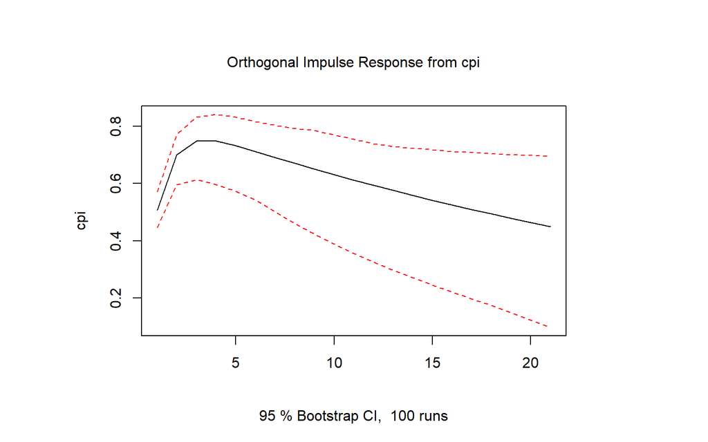

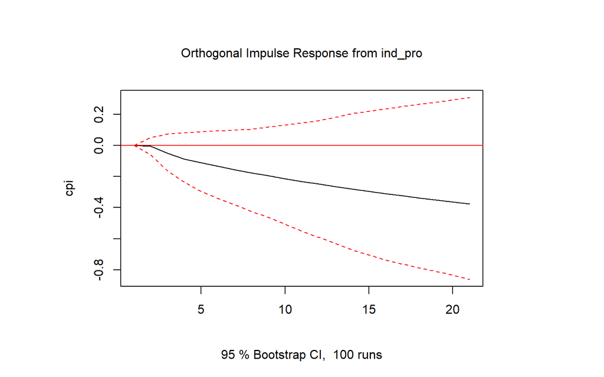

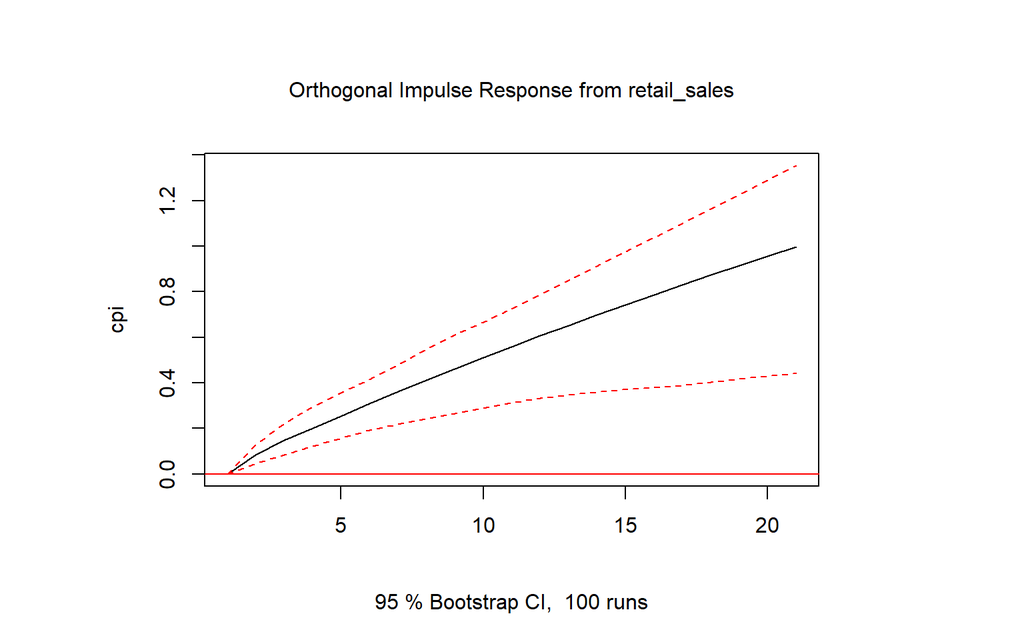

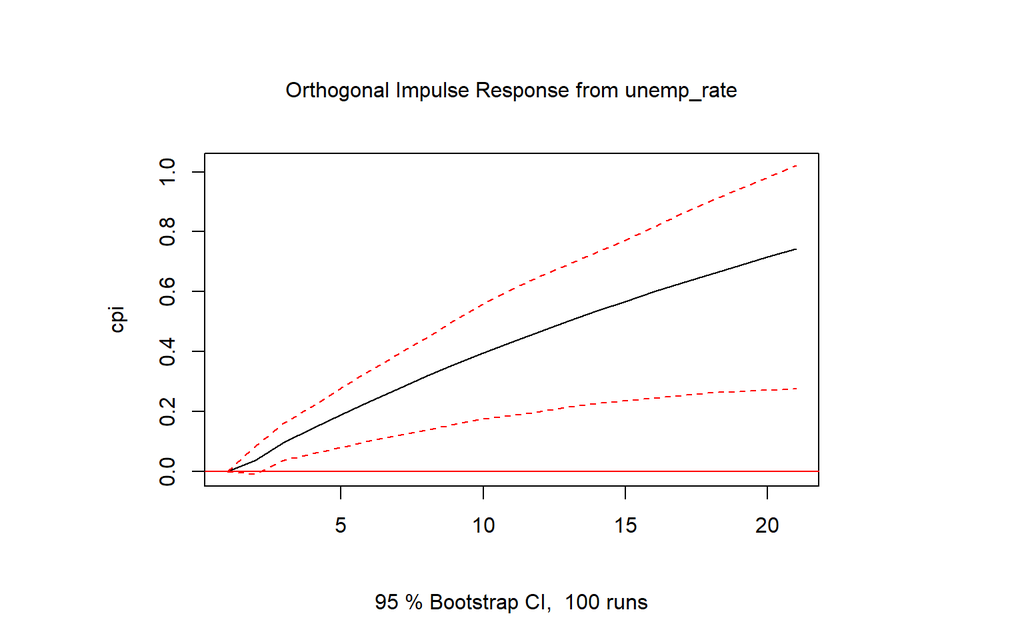

```r
# compute IRFs for all variables with bootstrapped confidence bands
irfs <- irf(vecm_var, response = "cpi", n.ahead = 20, ortho = TRUE, boot = TRUE, runs = 100)

plot(irfs)
```

## Forecast Error Variance Decomposition

```r
# compute fevd for a specified number of steps ahead
fevd_results <- fevd(vecm_var, n.ahead = 20)
round(fevd_results$cpi * 100, 2)
```

```
         cpi ind_pro retail_sales unemp_rate
 [1,] 100.00    0.00         0.00       0.00
 [2,]  98.88    0.00         0.93       0.19
 [3,]  96.87    0.19         2.12       0.82
 [4,]  94.39    0.51         3.49       1.61
 [5,]  91.47    0.86         5.09       2.57
 [6,]  88.15    1.23         6.93       3.69
 [7,]  84.50    1.61         8.95       4.94
 [8,]  80.62    2.00        11.10       6.28
 [9,]  76.61    2.39        13.34       7.66
[10,]  72.54    2.78        15.62       9.07
[11,]  68.48    3.15        17.90      10.47
[12,]  64.49    3.51        20.16      11.84
[13,]  60.62    3.85        22.38      13.16
[14,]  56.89    4.16        24.52      14.42
[15,]  53.34    4.46        26.59      15.62
[16,]  49.97    4.73        28.56      16.74
[17,]  46.79    4.98        30.44      17.79
[18,]  43.81    5.20        32.22      18.76
[19,]  41.02    5.41        33.91      19.67
[20,]  38.41    5.59        35.50      20.50
```

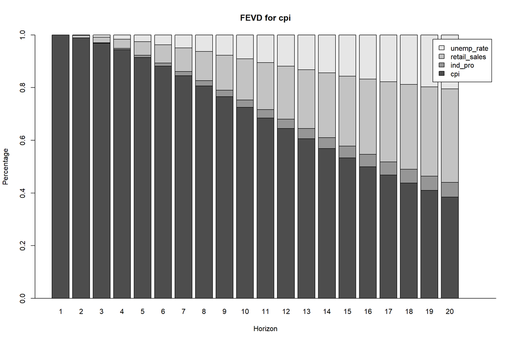

```r
plot(fevd_results, names = "cpi")
```

**Interpretation:** At short horizons, CPI forecast variance is almost entirely driven by its own shocks, confirming strong inflation inertia. Over longer horizons, own-shock variance declines and the contributions of external shocks grow, directly answering how each shock type matters over time. By horizon 20, the demand shock (retail_sales) accounts for 35.5% of CPI forecast variance, making it the dominant external driver. The labor market shock (unemp_rate) accounts for 20.5%, reinforcing the IRF finding that labor market conditions build inflationary pressure over time. The supply shock (ind_pro) accounts for only 5.6%, consistent with its short-run insignificance. This decomposition confirms that demand shocks are the primary external driver of U.S. inflation dynamics, with labor market shocks playing a secondary but meaningful long-run role.

# Conclusion

## Strengths

VECM performed well given the structure of the data. The Johansen trace test cleanly identified three cointegrating relationships, confirming that the series share long-run equilibrium paths rather than diverging independently. The error correction term in the CPI equation is statistically significant at the 1% level (ect1 = -0.03), confirming that when CPI deviates above its long-run equilibrium, it gradually corrects downward at roughly 3% per month. The VECM framework also provides rich interpretive tools like impulse response functions and forecast error variance decomposition, that clearly quantify how shocks to each variable propagate through the system over time. The FEVD reveals that by horizon 20, retail sales accounts for 35.5% of CPI forecast variance, a finding that a simple univariate ARIMA model would be entirely unable to surface.

## Weaknesses

The primary limitation is that all three diagnostic tests, serial correlation (Portmanteau), heteroscedasticity (ARCH), and normality (JB) all reject their null hypotheses strongly. These violations are largely due to structural breaks introduced by the COVID-19 pandemic and its aftermath (2020–2022), which produced extreme observations in every series. The impulse responses and variance decompositions are still interpretable as long-run estimates, but the confidence bands should be treated with caution. A more robust extension would incorporate a structural break dummy variable for 2020–2022 or restrict the sample to the post-2010 period to reduce the influence of crisis-era outliers.

## Insights

Three substantive economic insights emerged from this analysis. First, CPI has strong short-run momentum, a one-standard-deviation shock to CPI itself produces a persistent positive response that peaks around period 3 and remains elevated through period 20. Second, retail sales is the dominant long-run driver of inflation, its FEVD share grows steadily from near zero at short horizons to 35.5% at horizon 20, and its IRF shows the largest and most persistent positive effect on CPI. This aligns with demand-pull inflation theory, sustained consumer spending exerts upward pressure on prices over time. Third, unemployment has a surprising long-run positive effect on CPI despite being insignificant in the short-run VECM coefficient, suggesting its influence on inflation operates primarily through long-run equilibrium adjustment rather than contemporaneous dynamics.